# inclass-week8

Author

Ziyang Ye

### Activity 1

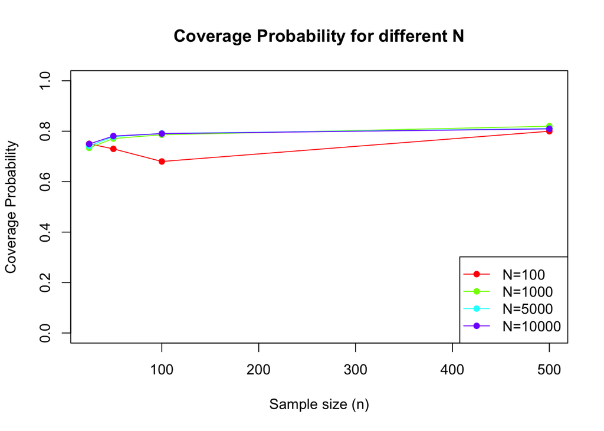

```r
library(truncnorm)
library(parallel)

# task1
generate_left_truncated_normal <- function(n, mu, sigma, theta) {
  samples <- numeric(0)
  while (length(samples) < n) {
    candidate <- rnorm(n - length(samples), mean = mu, sd = sigma)
    accepted <- candidate[candidate >= theta]
    samples <- c(samples, accepted)
  }
  return(samples)
}

# task2
estimate_theta <- function(sample) {
  return(min(sample))
}

# Pivot Bootstrap
pivot_bootstrap_ci <- function(sample, B = 1000, conf_level = 0.90) {
  theta_hat <- min(sample)
  bootstrap_min <- replicate(B, min(sample(sample, replace = TRUE)))
  pivot_samples <- bootstrap_min - theta_hat
  alpha <- (1 - conf_level) / 2
  q_lower <- quantile(pivot_samples, 1 - alpha)
  q_upper <- quantile(pivot_samples, alpha)

  ci_lower <- theta_hat - q_lower
  ci_upper <- theta_hat - q_upper

  return(c(ci_lower, ci_upper))
}

compute_coverage_parallel <- function(N_values, n_values, mu = 0, sigma = 2, theta = -1, B = 500, conf_level = 0.90) {
  results <- list()

  cores <- detectCores() - 1
  cl <- makeCluster(cores)

  # close connection if mistake
  on.exit(stopCluster(cl), add = TRUE)


  clusterExport(cl, c("generate_left_truncated_normal", "pivot_bootstrap_ci"))

  for (N in N_values) {
    coverage_prob <- numeric(length(n_values))
    names(coverage_prob) <- paste0("n=", n_values)

    for (i in seq_along(n_values)) {
      n <- n_values[i]

      coverages <- parLapply(cl, 1:N, function(j, n, mu, sigma, theta, B, conf_level) {
        set.seed(j)
        sample <- generate_left_truncated_normal(n, mu, sigma, theta)
        CI <- pivot_bootstrap_ci(sample, B, conf_level)
        as.integer((CI[1] <= theta) && (theta <= CI[2]))
      }, n=n, mu=mu, sigma=sigma, theta=theta, B=B, conf_level=conf_level)

      coverage_prob[i] <- mean(unlist(coverages))
    }
    results[[paste0("N=", N)]] <- coverage_prob
  }

  return(results)
}

# plot
plot_coverage_results <- function(coverage_results, n_values) {
  plot(NULL, xlim = range(n_values), ylim = c(0,1),
       xlab = "Sample size (n)", ylab = "Coverage Probability", type = "n",
       main = "Coverage Probability for different N")
  colors <- rainbow(length(coverage_results))
  legend_labels <- names(coverage_results)

  for (i in seq_along(coverage_results)) {
    lines(n_values, coverage_results[[i]], type = "o", col = colors[i], pch = 16)
  }

  legend("bottomright", legend = legend_labels, col = colors, lty = 1, pch = 16)
}

# close
closeAllConnections()

# small sample test
#N_values_test <- c(50, 100)
#n_values_test <- c(25, 50)
#coverage_results_parallel_test <- compute_coverage_parallel(N_values_test, n_values_test, B = 100)

#plot_coverage_results(coverage_results_parallel_test, n_values_test)


# full test
N_values_full <- c(100, 1000, 5000, 10000)
n_values_full <- c(25, 50, 100, 500)
coverage_results_parallel_full <- compute_coverage_parallel(N_values_full, n_values_full, B = 500)
plot_coverage_results(coverage_results_parallel_full, n_values_full)
```

## Activity 2

Define the indicator function: $I\left(\theta \in [\hat{\theta}^{\,\text{lo}},\,\hat{\theta}^{\,\text{up}}]\right) = \begin{cases}1, & \text{if}\quad \theta \in[\hat{\theta}^{\,\text{lo}},\,\hat{\theta}^{\,\text{up}}], \\[6pt]0, & \text{otherwise}.\end{cases}$

The Monte Carlo simulation approximates the expectation: $\mathbb{E}\left[I\left(\theta \in [\hat{\theta}^{\,\text{lo}},\,\hat{\theta}^{\,\text{up}}]\right)\right]$ which can equivalently be expressed as the coverage probability: $P\left(\hat{\theta}^{\,\text{lo}} \leq \theta \leq \hat{\theta}^{\,\text{up}}\right)$

Explicitly, this probability can be written as an integral: $P\left(\hat{\theta}^{\,\text{lo}} \leq \theta \leq \hat{\theta}^{\,\text{up}}\right) = \int_{\mathbb{R}^n} I\left(\hat{\theta}^{\,\text{lo}}(\mathbf{x}) \leq \theta \leq \hat{\theta}^{\,\text{up}}(\mathbf{x})\right)\prod_{i=1}^{n}f(x_i;\mu,\sigma,\theta)\,dx_1 dx_2 \dots dx_n$

where:

- $\mathbf{x} = (x_1,x_2,\dots,x_n)$ is a random sample drawn from the left-truncated normal distribution with PDF $f(x;\mu,\sigma,\theta)$.
- $\hat{\theta}^{\,\text{lo}}(\mathbf{x})$ and $\hat{\theta}^{\,\text{up}}(\mathbf{x})$ are the lower and upper endpoints of the bootstrap confidence interval computed from sample $\mathbf{x}$.

the Monte Carlo estimate of the coverage probability is computed as the empirical mean of the indicator function over $N$ simulation replications: $\frac{1}{N}\sum_{j=1}^{N} I\left(\hat{\theta}^{\,\text{lo}}(\mathbf{x}^{(j)}) \leq \theta \leq \hat{\theta}^{\,\text{up}}(\mathbf{x}^{(j)})\right)$

where $\mathbf{x}^{(j)}$, for $j = 1, 2, \dots, N$, are independent random samples drawn from the given left-truncated normal distribution.